# Script and Markdown Files

2023 Bio R Workshop

Author

**Prof. Rey R. Cuenca**  
*Math-Stat Dept., MSU-IIT*

## Scripts

### Opening R Script Files

R script files are files with extension `.R`. This files are directly opened in the Source Pane.

[figure not shown]

Figure 1: A sample R script file named `sample-script.R` opened in the Source Pane.

### Editing Script Files

Typical things you can do on a script file.

1. Writing code lines
   - Insert a new code chunk: `Ctrl + Alt + I` or `Option + Command + I`
   - Auto-completion (on snippets and function arguments) using the `Tab` button.
   - Insert assignment operator `<-` : `Alt + - (minus)` or `Command + - (minus)`
   - When a cursor is located to an R object,
     1. pressing `F1` navigates to the help page of this object and
     2. pressing `F2` opens the definition of this object.
   - Insert pipe (`%>%`) operator: `Ctrl + Shift + M` or `Shift + Command + M`
2. Run code lines by
   - Run all codes in the current chunk: `Ctrl + Shift + Enter` or `Shift + Command + Return`
   - Run the code in the current line where the cursor is located: `Ctrl + Enter` or `Shit + Return`
3. Comment code lines
   - Comment out the current line where the cursor is located or the entire highlighted lines: `Cntrl + Shift + C` or `Shift + Command + C`

## Markdown

### Creating Markdown Files

Markdown is a lightweight markup language use to create formatted texts. Markdown files are files used to write Markdown language. In R, we are able to read/write at least three types of markdown files:

1. Markdown `.md`

   We can open `.md` files the same as how we open script files.

[figure not shown]

   Figure 2: The `README.md` file of the workshops github repository.

2. RMarkdown `.rmd`

[figure not shown]

   (a) Create the file using plus-document icon.

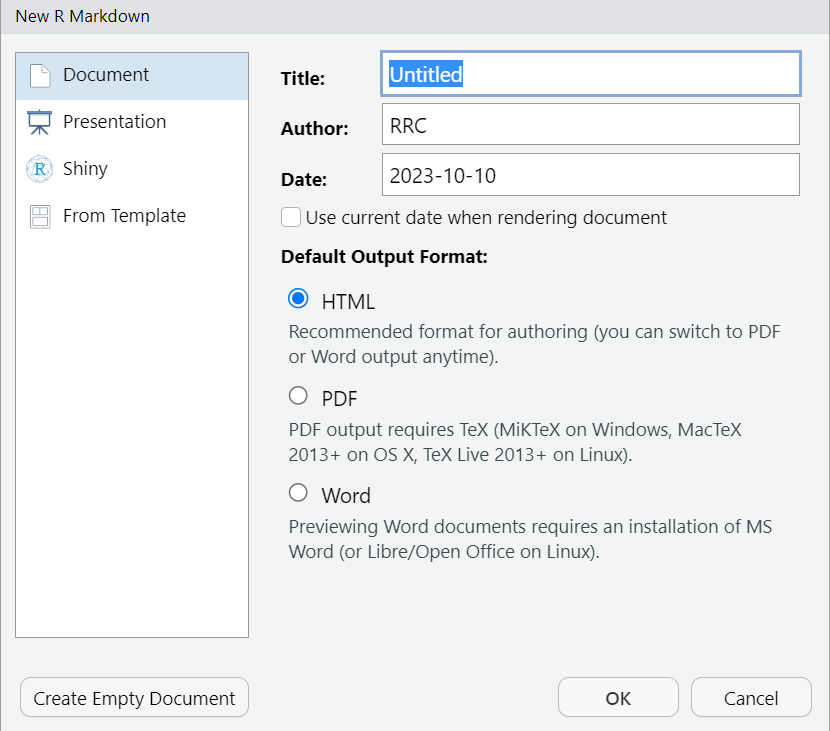

   Specfying title, author, date and output format.

   Figure 3: Creating an R Markdown file using RStudio.

[figure not shown]

   Figure 4: Parts of an R Markdown file.

3. Quarto Markdown `.qmd`

   A quarto markdown file is created the same way as the R markdown file except that the file extension is `.qmd` and is a much richer version compared to `.rmd`. Moreover, almost all syntax in `.rmd` works in `.qmd`.

### Rendering Markdown Files

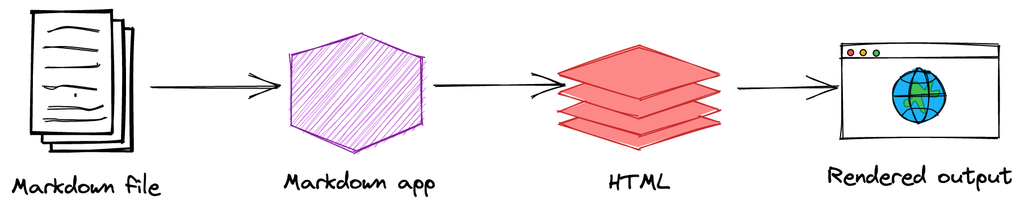

Figure 5: Flowchart when rendering a markdown file.

[figure not shown]

Figure 6: A worklow without R

[figure not shown]

Figure 7: A workflow using R streamlined using markdown files.